# Plotting Multi Season Occupancy Modeling Results in R Using ggplot

### First load required packages

**If you need to install the packages, you can do so directly in R Studio (Tools –> Install Packages or Packages –> Install), or you can use commands like these in your R Script: install.packages(“unmarked”). Once downloaded, you’ll need to call the packages you want to use in R using library(packagename) or require(packagename). When you call a package, R automatically calls other packages that are needed.**

```r
library(unmarked) # need this for fitting an occupancy model
```

```r
library(ggplot2) # need this for making plots
library(reshape2) # need this for some data manipulation
```

### Now import a data set

**We’ll use the Grand Skinks data for this example.**

```r
options(scipen=999) # suppress printing scientific notation
GrandSkinks<-read.csv("MultiSeasonOccupancy_GrandSkinks.csv",header=TRUE)
names(GrandSkinks)
```

```
## [1] "Site"    "Time"    "Occ1"    "Occ2"    "Occ3"    "Tussock" "Pasture" "HabType"
```

```r
print(head(GrandSkinks),row.names=FALSE)
```

```
##  Site Time Occ1 Occ2 Occ3 Tussock Pasture HabType
##     1    1    0    0    0       0       1 Pasture
##     2    1    0    0    0       0       1 Pasture
##     3    1    0    0    0       0       1 Pasture
##     4    1    0   NA   NA       0       1 Pasture
##     5    1    0   NA   NA       0       1 Pasture
##     6    1    0   NA   NA       0       1 Pasture
```

### Now subset the data frame

**Here, we’re separating the observation data and site-level covariates, and we also create a Year-specific indicator variable. We also need to re-format the observation data slightly. There are no observation-level covariates here.**

```r
y<-subset(GrandSkinks, select=c(-Tussock,-Pasture,-HabType)) # subset columns for observation data
y <- melt(y, id.vars = c("Site", "Time")) # first melt the observation data
y <- y[with(y, order(Time, Site, variable)),] # then re-order it
names(y)<- c("Site", "Time", "Occasion", "y") # rename the columns
yfin <-dcast(y, Site ~ Time + Occasion, value.var = "y") # then transpose the data using dcast
head(yfin)
```

```
##   Site 1_Occ1 1_Occ2 1_Occ3 2_Occ1 2_Occ2 2_Occ3 3_Occ1 3_Occ2 3_Occ3 4_Occ1 4_Occ2 4_Occ3 5_Occ1
## 1    1      0      0      0      0      0      0      0      0     NA      0      0      0      0
## 2    2      0      0      0      0      0     NA      0      0      0      0      0      0      0
## 3    3      0      0      0      0      0     NA      0      0      0      0      0      0      0
## 4    4      0     NA     NA      0     NA     NA      0     NA     NA      0      0     NA      0
## 5    5      0     NA     NA     NA     NA     NA     NA     NA     NA     NA     NA     NA      0
## 6    6      0     NA     NA     NA     NA     NA     NA     NA     NA     NA     NA     NA      0
##   5_Occ2 5_Occ3
## 1      0      0
## 2      0      0
## 3      0      0
## 4     NA     NA
## 5     NA     NA
## 6     NA     NA
```

```r
max(GrandSkinks$Site) # figure out how many sites there are (we would know this already)
```

```
## [1] 338
```

```r
sitecovs<-subset(GrandSkinks[1:338,], select=c(Tussock, Pasture, HabType)) # subset columns for site-level covariates. There are 338 sites, so we only need the first 338 rows of GrandSkinks
head(sitecovs)
```

```
##   Tussock Pasture HabType
## 1       0       1 Pasture
## 2       0       1 Pasture
## 3       0       1 Pasture
## 4       0       1 Pasture
## 5       0       1 Pasture
## 6       0       1 Pasture
```

```r
Year <- matrix(c('01','02','03','04','05'),nrow(yfin),5,byrow=TRUE) # Create Year covariate
head(Year)
```

```
##      [,1] [,2] [,3] [,4] [,5]
## [1,] "01" "02" "03" "04" "05"
## [2,] "01" "02" "03" "04" "05"
## [3,] "01" "02" "03" "04" "05"
## [4,] "01" "02" "03" "04" "05"
## [5,] "01" "02" "03" "04" "05"
## [6,] "01" "02" "03" "04" "05"
```

### Now we can create an unmarkedMultFrame for a multi season occupancy model.

```r
SkinkDat<-unmarkedMultFrame(y = yfin[,2:16],numPrimary=5, siteCovs=sitecovs,yearlySiteCovs = list(Year=Year))
head(SkinkDat@y)
```

```
##      1_Occ1 1_Occ2 1_Occ3 2_Occ1 2_Occ2 2_Occ3 3_Occ1 3_Occ2 3_Occ3 4_Occ1 4_Occ2 4_Occ3 5_Occ1
## [1,]      0      0      0      0      0      0      0      0     NA      0      0      0      0
## [2,]      0      0      0      0      0     NA      0      0      0      0      0      0      0
## [3,]      0      0      0      0      0     NA      0      0      0      0      0      0      0
## [4,]      0     NA     NA      0     NA     NA      0     NA     NA      0      0     NA      0
## [5,]      0     NA     NA     NA     NA     NA     NA     NA     NA     NA     NA     NA      0
## [6,]      0     NA     NA     NA     NA     NA     NA     NA     NA     NA     NA     NA      0
##      5_Occ2 5_Occ3
## [1,]      0      0
## [2,]      0      0
## [3,]      0      0
## [4,]     NA     NA
## [5,]     NA     NA
## [6,]     NA     NA
```

### And now fit a multiseason occupancy model in unmarked.

```r
(SkinkMod<-colext(psiformula=~HabType,gammaformula=~Year+HabType,epsilonformula=~Year+HabType,pformula=~Year,data=SkinkDat))
```

```
##
## Call:
## colext(psiformula = ~HabType, gammaformula = ~Year + HabType,
##     epsilonformula = ~Year + HabType, pformula = ~Year, data = SkinkDat)
##
## Initial:
##                Estimate    SE     z     P(>|z|)
## (Intercept)       -1.22 0.237 -5.14 0.000000277
## HabTypeTussock     1.19 0.289  4.12 0.000037640
##
## Colonization:
##                Estimate    SE      z      P(>|z|)
## (Intercept)      -2.548 0.422 -6.044 0.0000000015
## Year02           -2.079 1.402 -1.483 0.1381144241
## Year03           -0.508 0.536 -0.948 0.3433149037
## Year04           -0.136 0.499 -0.273 0.7851420602
## HabTypeTussock    0.882 0.366  2.411 0.0158992727
##
## Extinction:
##                Estimate    SE       z   P(>|z|)
## (Intercept)     -2.0333 0.507 -4.0106 0.0000606
## Year02           0.0116 0.669  0.0173 0.9861796
## Year03           0.7530 0.571  1.3189 0.1872187
## Year04           0.9282 0.632  1.4698 0.1416203
## HabTypeTussock  -0.7365 0.371 -1.9879 0.0468256
##
## Detection:
##             Estimate    SE      z P(>|z|)
## (Intercept)   0.7929 0.271  2.927 0.00342
## Year02       -0.1597 0.333 -0.479 0.63159
## Year03       -0.0102 0.330 -0.031 0.97527
## Year04        0.8812 0.415  2.122 0.03386
## Year05       -0.1502 0.378 -0.397 0.69129
##
## AIC: 1744.414
```

### To make predictions from the model, we’ll first create a “fake” data set and predict local extinction, colonization, and detection as a function of various site- and year-specific covariates.

**Note the use of expand.grid(), which is a handy function for creating data sets.**

```r
newdata<-expand.grid(Year=c('01','02','03','04'),HabType=c("Pasture", "Tussock"))
print(newdata)
```

```
##   Year HabType
## 1   01 Pasture
## 2   02 Pasture
## 3   03 Pasture
## 4   04 Pasture
## 5   01 Tussock
## 6   02 Tussock
## 7   03 Tussock
## 8   04 Tussock
```

### Now we’re ready to make predictions and plots for local extinction, local colonization, and detection.

**Note that we have to specify “col”, “ext”, or “det” when we want to make predictions for colonization, extinction, and detection, respectively. Also, we can use “se.fit = T” (although I think predict does this automatically for unmarked objects) to calculated SEs 95% CIs for each prediction, and we can use “appendData = T” to append the fake data to the data frame produced by predict; this is handy for plotting purposes as you’ll see below.**

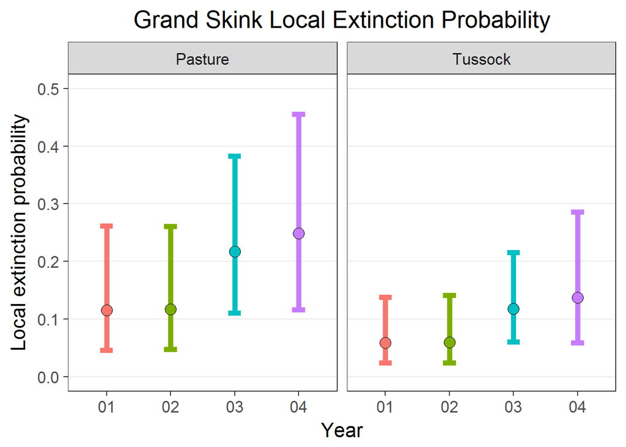

```r
Pred.Ext<-predict(SkinkMod,type='ext',newdata=newdata, se.fit = T, appendData = T)

(ExtPlot<-ggplot(Pred.Ext, aes(Year,Predicted, color = Year)) + geom_errorbar(aes(ymin = lower, ymax = upper), width=0.2, size = 2) + geom_point(aes(fill = Year),colour = "black", shape = 21, size = 4) + facet_grid(.~HabType) + labs(title="Grand Skink Local Extinction Probability",x="Year",y="Local extinction probability") + ylim(0,0.5) + theme_bw(base_size = 16) + theme(plot.title = element_text(hjust = 0.5)) + theme(panel.grid.major.x = element_blank()) + theme(panel.grid.minor.x = element_blank()) + theme(panel.grid.minor.y = element_blank()) + theme(legend.position = "none"))
```

```r
ggsave("ExtPlot.jpg", ExtPlot, height=8,width=12,dpi=600)
```

### Now local colonization

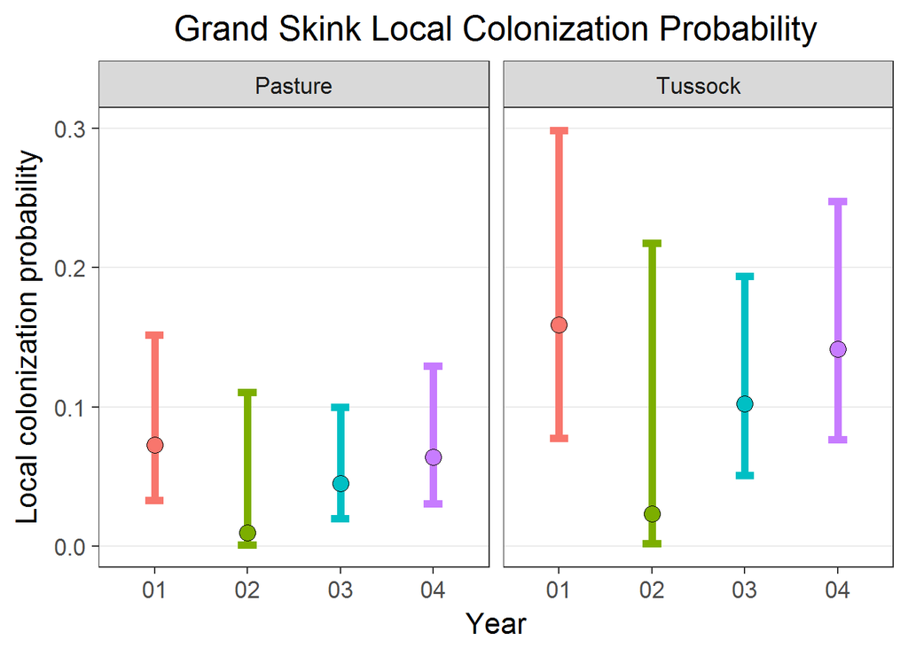

```r
Pred.Col<-predict(SkinkMod,type='col',newdata=newdata, se.fit = T, appendData = T)

(ColPlot<-ggplot(Pred.Col, aes(Year,Predicted, color = Year)) + geom_errorbar(aes(ymin = lower, ymax = upper), width=0.2, size = 2) + geom_point(aes(fill = Year),colour = "black", shape = 21, size = 4) + facet_grid(.~HabType) + labs(title="Grand Skink Local Colonization Probability",x="Year",y="Local colonization probability") + ylim(0,0.3) + theme_bw(base_size = 16) + theme(plot.title = element_text(hjust = 0.5)) + theme(panel.grid.major.x = element_blank()) + theme(panel.grid.minor.x = element_blank()) + theme(panel.grid.minor.y = element_blank()) + theme(legend.position = "none"))
```

```r
ggsave("ColPlot.jpg", ColPlot, height=8,width=12,dpi=600)
```

### And finally detection

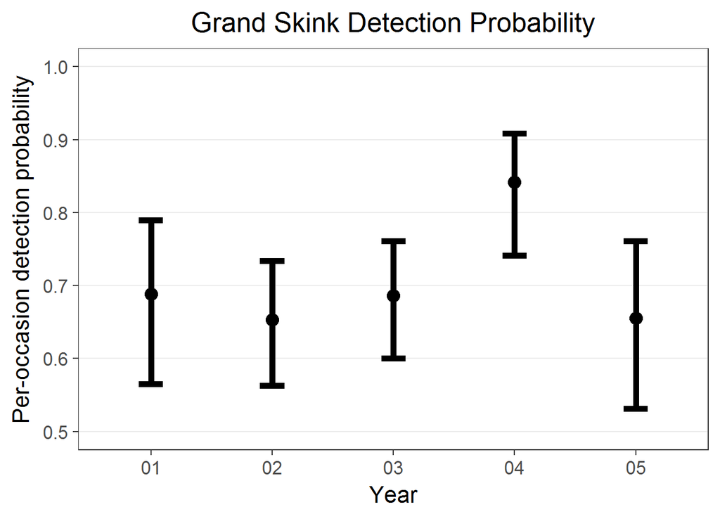

```r
newdata2<-expand.grid(Year=c('01','02','03','04','05'))
Pred.Det<-predict(SkinkMod,type='det',newdata=newdata2, se.fit = T, appendData = T)
(DetPlot<-ggplot(Pred.Det, aes(Year,Predicted)) + geom_point(size=4) + geom_errorbar(aes(ymin = lower, ymax = upper), width=0.2, size = 2) + labs(title="Grand Skink Detection Probability", x="Year",y="Per-occasion detection probability") + ylim(0.5,1.0) + theme_bw(base_size = 16) + theme(plot.title = element_text(hjust = 0.5)) + theme(panel.grid.major.x = element_blank()) + theme(panel.grid.minor.x = element_blank()) + theme(panel.grid.minor.y = element_blank()) + theme(legend.position = "none"))
```

```r
ggsave("DetPlot.jpg",DetPlot, height=8, width=12, dpi=600)
```

### Now we’ll make another plot, only this time for the number of occupied sites in each year, which is a derived parameter.

**This is a little bit complicated, and there may very well be a simpler way to do this, but in any event the code below calculates the number of occupied sites in each year along with 95% confidence intervals, and then it creates a plot.**

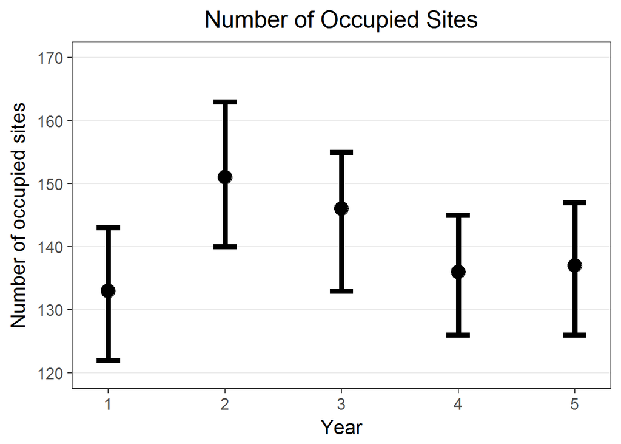

```r
sitesOccupiedSim <- function(psi.c, nsim) {
  M <- length(psi.c)
  sims <- matrix(NA, M, nsim)
  post <- rep(0, M+1)
  names(post) <- 0:M
  for(i in 1:nsim) {
    sims[,i] <- rbinom(M,1,psi.c)
  }
  s <- colSums(sims)
  sf <- table(s)
  post[names(sf)]<- sf
  post <- post/nsim
  return(post)
}
psi.c <- bup(ranef(SkinkMod))
psi.c1<-psi.c[,1]
psi.c2<-psi.c[,2]
psi.c3<-psi.c[,3]
psi.c4<-psi.c[,4]
psi.c5<-psi.c[,5]

occ1<-sitesOccupiedSim(psi.c1,10000)
occ2<-sitesOccupiedSim(psi.c2,10000)
occ3<-sitesOccupiedSim(psi.c3,10000)
occ4<-sitesOccupiedSim(psi.c4,10000)
occ5<-sitesOccupiedSim(psi.c5,10000)

q1<-cumsum(occ1)
OccSites1 <- c(Year=1, Est. = as.integer(names(which.max(occ1))),
               lowerCI = as.integer(names(q1)[max(which(q1 < 0.025))]),
               upperCI = as.integer(names(q1)[min(which(q1 > 0.975))]))
q2<-cumsum(occ2)
OccSites2 <- c(Year=2, Est. = as.integer(names(which.max(occ2))),
               lowerCI = as.integer(names(q2)[max(which(q2 < 0.025))]),
               upperCI = as.integer(names(q2)[min(which(q2 > 0.975))]))
q3<-cumsum(occ3)
OccSites3 <- c(Year=3, Est. = as.integer(names(which.max(occ3))),
               lowerCI = as.integer(names(q3)[max(which(q3 < 0.025))]),
               upperCI = as.integer(names(q3)[min(which(q3 > 0.975))]))
q4<-cumsum(occ4)
OccSites4 <- c(Year=4,Est. = as.integer(names(which.max(occ4))),
               lowerCI = as.integer(names(q4)[max(which(q4 < 0.025))]),
               upperCI = as.integer(names(q4)[min(which(q4 > 0.975))]))
q5<-cumsum(occ5)
OccSites5 <- c(Year=5,Est. = as.integer(names(which.max(occ5))),
               lowerCI = as.integer(names(q5)[max(which(q5 < 0.025))]),
               upperCI = as.integer(names(q5)[min(which(q5 > 0.975))]))

OccupiedSites<-as.data.frame(rbind(OccSites1,OccSites2,OccSites3,OccSites4,OccSites5))

(OccPlot<-ggplot(OccupiedSites,aes(Year,Est.)) + geom_errorbar(aes(ymin = lowerCI, ymax = upperCI), width=0.2, size = 2) + geom_point(colour = "black", shape = 20, size = 8) + labs(title="Number of Occupied Sites",x="Year",y="Number of occupied sites") + ylim(120,170) + theme_bw(base_size = 16) + theme(plot.title = element_text(hjust = 0.5)) + theme(panel.grid.major.x = element_blank()) + theme(panel.grid.minor.x = element_blank()) + theme(panel.grid.minor.y = element_blank()) + theme(legend.position = "none"))
```

```r
ggsave("OccupiedSitesPlot.jpg", OccPlot, height=8,width=12,dpi=600)
```